# Analysis of the road accidents in UK (2004-2009)

## Plotting data.

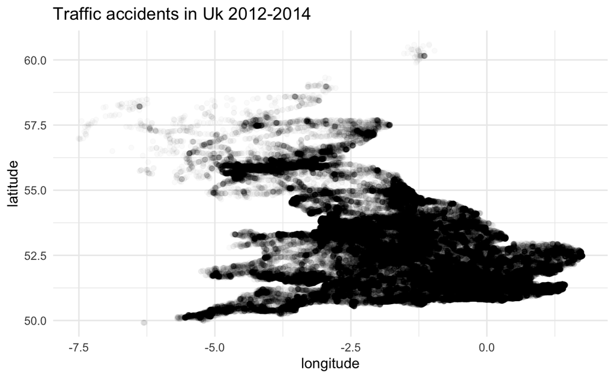

```r
accidents_2012_to_2014 %>%
  ggplot(aes(x= longitude,y=latitude))+
  geom_point(color = "black",alpha = .02) +
  theme_minimal()+
  labs(title = "Traffic accidents in Uk 2012-2014")
```

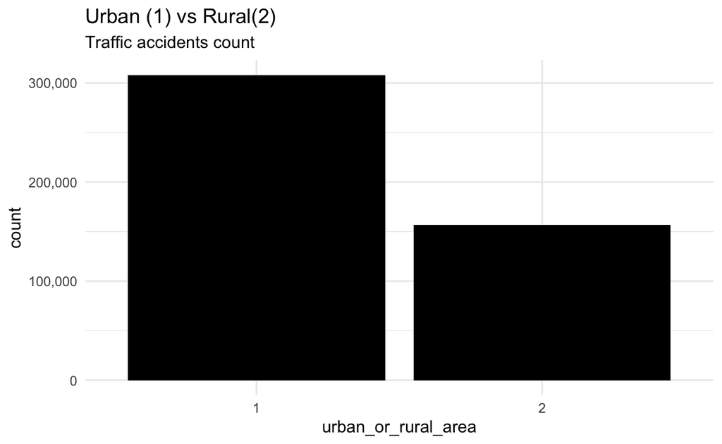

```r
accidents_2012_to_2014 %>%
  ggplot(aes(urban_or_rural_area)) +
  geom_bar(fill = "black") +
  scale_y_continuous(labels = scales::comma)+
  theme_minimal()+
    labs(title = "Urban (1) vs Rural(2)",
         subtitle = "Traffic accidents count")
```

From the plot above we can see that twice as much accidents happens in urban area than rural.

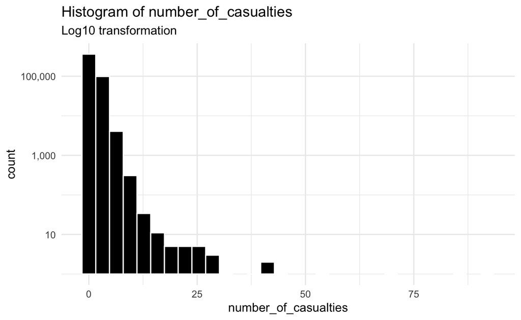

```r
accidents_2012_to_2014 %>%
  ggplot(aes(number_of_casualties)) +
  geom_histogram(fill = "black",color= "white") +
  scale_y_continuous(labels = scales::comma, trans ="log10")+
  theme_minimal()+
    labs(title = "Histogram of number_of_casualties",
         subtitle = "Log10 transformation")
```

Number of casualties is right skewed which can have an impact on model building process later on.

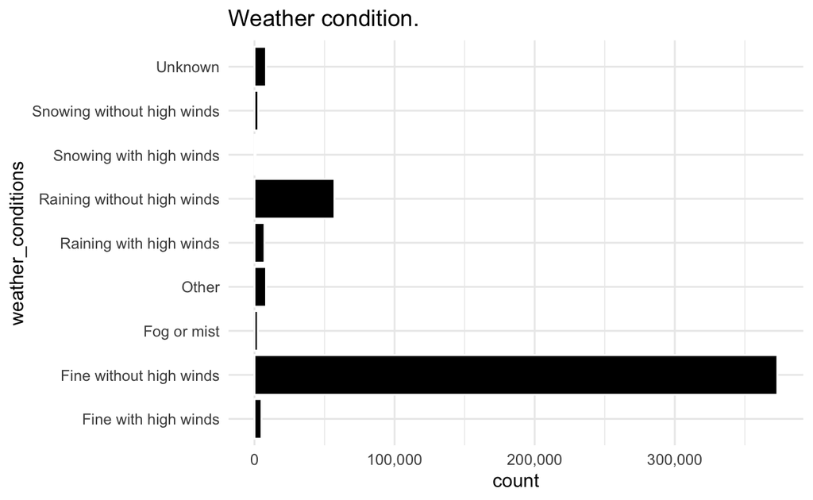

```r
accidents_2012_to_2014 %>%
  ggplot(aes(weather_conditions)) +
  geom_bar(fill = "black",color= "white") +
  scale_y_continuous(labels = scales::comma)+
  theme_minimal()+
  coord_flip()+
    labs(title = "Weather condition.")
```

Looks like huge amount of accidents happens in normal conditions.

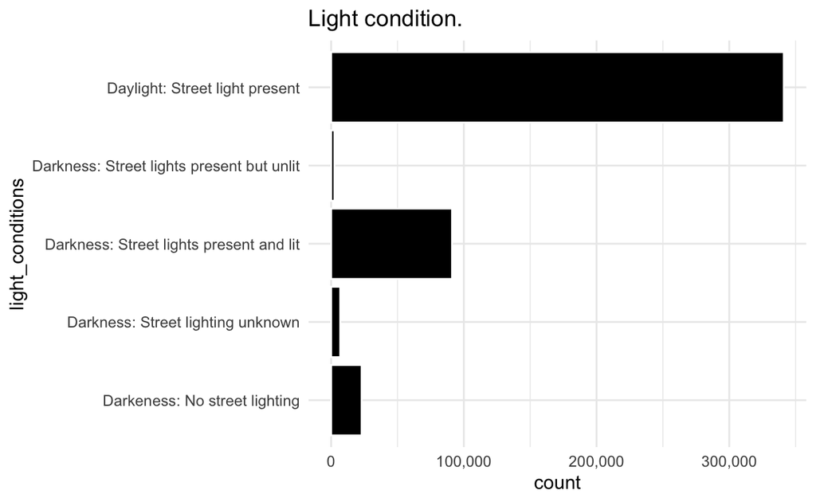

```r
accidents_2012_to_2014 %>%
  ggplot(aes(light_conditions)) +
  geom_bar(fill = "black",color= "white") +
  scale_y_continuous(labels = scales::comma)+
  theme_minimal()+
  coord_flip()+
    labs(title = "Light condition.")
```

# Model building.

## Picking variables for the model.

This are the variables which I decided to choose for the model. By no means this is a closed set and it can change in future depends on the results.

```r
accidents_df <-  accidents_2012_to_2014 %>%
  select(-accident_index,
         -x1st_road_number,
         -x2nd_road_number,
         -did_police_officer_attend_scene_of_accident,
         -location_easting_osgr,
         -location_northing_osgr,
         -local_authority_highway,
         -lsoa_of_accident_location,
         -police_force,
         -local_authority_district,
         -x1st_road_class,
         -x2nd_road_class,
         -accident_severity) %>%
  mutate(h_of_accident = lubridate::hour(time),# extracting hour only from time column.
         month_of_accident = lubridate::month(date)) %>%  # extracting month only from time column.
  select(-date,-time) %>%
  drop_na()
```

## Target variable.

We will try to understand if conditions captured in the variables can predict if number of casualties in greater than 1.

```r
accidents_df <-  accidents_df %>%
  mutate(number_of_casualties = if_else(number_of_casualties == 1, "one","more"))
```

Quick check revels that target variable highly unbalanced. This will have to be addressed later.

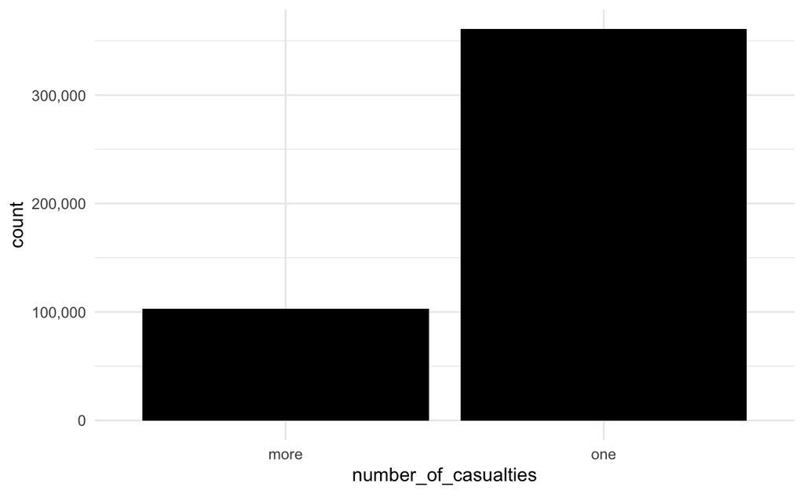

```r
accidents_df %>%
  ggplot(aes(number_of_casualties))+
  geom_bar(fill = "black",show.legend = F)+
  scale_y_continuous(labels = scales::comma)+
  theme_minimal()
```

## Initial data split

Data split with stratification set to number_of_casualties.

```r
df_split <- initial_split(accidents_df,strata = number_of_casualties )
```

Creating **training set.**

```r
data_train <- training(df_split)
```

Creating **testing set.**

```r
data_test <- testing(df_split)
```

## Data preprocessing with recepies.

Preparation of data for modeling. Removing NA`s, zero variance observation, and down sampling based on outcome variable.

```r
accidents_rec <-
  recipe(number_of_casualties ~.,data = data_train) %>%
  step_normalize(all_numeric(), -all_outcomes()) %>%
  step_dummy(all_nominal(), -all_outcomes()) %>%
  step_zv(all_numeric(),-all_outcomes(),) %>%
  step_downsample(all_outcomes())
```

Quick check that unbalanced data problem is solved.

```r
accidents_rec %>% prep() %>% juice() %>% count(number_of_casualties)
```

```
# A tibble: 2 x 2
  number_of_casualties     n
  <fct>                <int>
1 more                 77219
2 one                  77219
```

## Cross validation sets.

```r
cv_folds <- vfold_cv(data_train, v = 5, strata = number_of_casualties)
```

## Building models specifications.

I will try three models:

- logistic regression
- random forest
- xgboost

### Model specification for logistic regression.

```r
log_spec <-
  logistic_reg() %>%
  set_engine("glm") %>%
  set_mode("classification")
```

### Model specification for random forest.

```r
rf_spec <-
  rand_forest() %>%
  set_engine("ranger",importance = "impurity") %>%
  set_mode("classification")
```

### Model specification for xgboost.

```r
xgb_spec <-
  boost_tree() %>%
  set_engine("xgboost") %>%
  set_mode("classification")
```

## Building workflows.

### Logistic regression workflow

```r
log_workflow <-
  workflow() %>%
  add_recipe(accidents_rec) %>%
  add_model(log_spec)
```

### Random forest workflow.

```r
rf_workflow <-
  workflow() %>%
  add_recipe(accidents_rec) %>%
  add_model(rf_spec)
```

### Xgboost workflow.

```r
xgb_workflow <-
  workflow() %>%
  add_recipe(accidents_rec) %>%
  add_model(xgb_spec)
```

## Fitting re-samples.

### Fitting logistic regression workflow

```r
log_res <-
  log_workflow %>%
  fit_resamples(
    resamples = cv_folds,
    metrics = metric_set(
      accuracy,
      roc_auc,
      sens,
      specificity),
    control = control_resamples(
      save_pred = TRUE)
    )
```

### Fitting Random Forrest workflow.

```r
rf_res <-
  rf_workflow %>%
  fit_resamples(
    resamples = cv_folds,
    metrics = metric_set(
     accuracy,
      roc_auc,
      sens,
      specificity),
    control = control_resamples(
      save_pred = TRUE)
    )
```

```r
rf_res
```

```
# Resampling results
# 5-fold cross-validation using stratification
# A tibble: 5 x 5
  splits            id    .metrics      .notes       .predictions
  <list>            <chr> <list>        <list>       <list>
1 <split [278355/6… Fold1 <tibble [4 ×… <tibble [0 … <tibble [69,590 …
2 <split [278356/6… Fold2 <tibble [4 ×… <tibble [0 … <tibble [69,589 …
3 <split [278356/6… Fold3 <tibble [4 ×… <tibble [0 … <tibble [69,589 …
4 <split [278356/6… Fold4 <tibble [4 ×… <tibble [0 … <tibble [69,589 …
5 <split [278357/6… Fold5 <tibble [4 ×… <tibble [0 … <tibble [69,588 …
```

### Fitting xgboost workflow

```r
xgb_res <-
  xgb_workflow %>%
  fit_resamples(
    resamples = cv_folds,
    metrics = metric_set(
      accuracy,
      roc_auc,
      sens,
      specificity),
    control = control_resamples(
      save_pred = TRUE)
    )
```

### Collecting metrics

```r
models_comp <- bind_rows(
rf_res %>%  collect_metrics(summarize =T) %>%
  mutate(model = "Random Forest"),
log_res %>%  collect_metrics() %>%
  mutate(model = "Logistic Regression"),
xgb_res %>% collect_metrics() %>%
  mutate(model = "XGBoost" )
) %>%
  select(model, .metric,mean) %>%
  pivot_wider(names_from = model,values_from = mean)
```

Comparing metrics for three models

```r
models_comp %>% gt()
```

| .metric | Random Forest | Logistic Regression | XGBoost |
| --- | --- | --- | --- |
| accuracy | 0.6538217 | 0.6702553 | 0.6458205 |
| roc_auc | 0.7268075 | 0.7037167 | 0.7167037 |
| sens | 0.6846242 | 0.6014582 | 0.6793792 |
| spec | 0.6450359 | 0.6898783 | 0.6362485 |

**Plotting results**

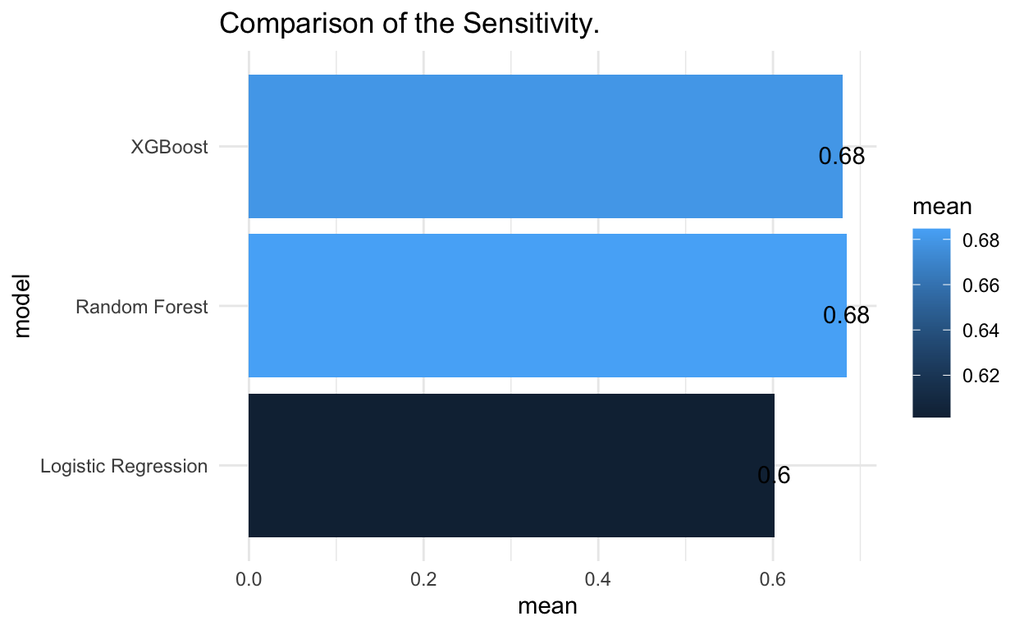

```r
models_comp %>%
  filter(.metric == "sens") %>%
  pivot_longer(names_to = "model",values_to = "mean",cols = c(-.metric)) %>%
  ggplot(aes(model,mean))+
  geom_col(aes(fill = mean))+
  coord_flip()+
  geom_text(aes(label = round(mean,2)), vjust=1)+
  theme_minimal()+
  labs(title = "Comparison of the Sensitivity.")
```

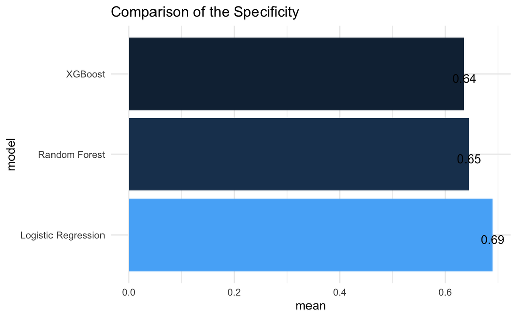

```r
models_comp %>%
  filter(.metric == "spec") %>%
  pivot_longer(names_to = "model",values_to = "mean",cols = c(-.metric)) %>%
  ggplot(aes(model,mean))+
  geom_col(aes(fill = mean),show.legend = F)+
  coord_flip()+
  geom_text(aes(label = round(mean,2)), vjust=1)+
  theme_minimal()+
  labs(title = "Comparison of the Specificity")
```

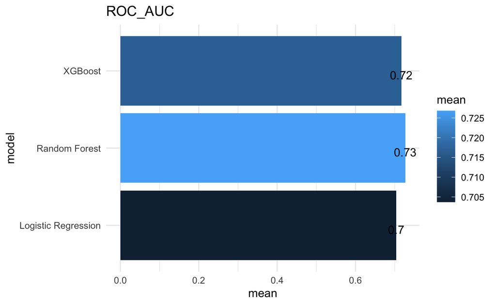

```r
models_comp %>%
  filter(.metric == "roc_auc") %>%
  pivot_longer(names_to = "model",values_to = "mean",cols = c(-.metric)) %>%
  ggplot(aes(model,mean))+
  geom_col(aes(fill = mean))+
  coord_flip()+
  geom_text(aes(label = round(mean,2)), vjust=1)+
  theme_minimal()+
  labs(title= "ROC_AUC")
```

Based on plots above I decide to choose Random Forest model for final fit.

# Last evaluation of the Random Forest model.

```r
last_fit_rf <- last_fit(rf_workflow,split = df_split,
         metrics = metric_set(sens,roc_auc),save_pred = T)
```

Collecting metrics for last fit.

```r
last_fit_rf %>% collect_metrics() %>% gt()
```

| .metric | .estimator | .estimate | .config |
| --- | --- | --- | --- |
| sens | binary | 0.6921523 | Preprocessor1_Model1 |
| roc_auc | binary | 0.7297823 | Preprocessor1_Model1 |

Since the metrics of the last fit looks similar to metrics from the validation set we would have pretty high confidence that our model would do good job in predicting target variable supplied with new data,

# Variable importance.

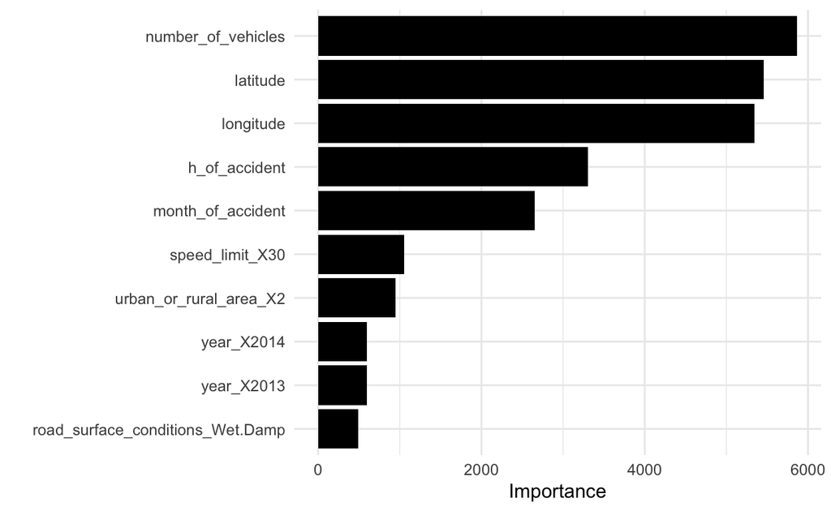

```r
last_fit_rf %>%
  pluck(".workflow",1) %>%
  pull_workflow_fit() %>%
  vip(fill = "black")+
  theme_minimal()
```

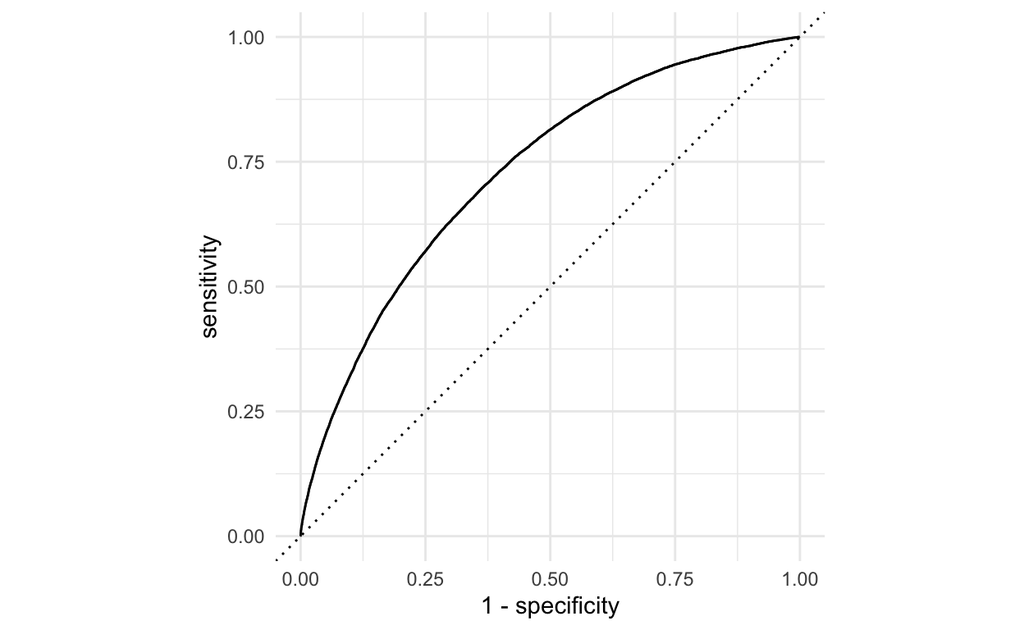

```r
last_fit_rf %>%
  collect_predictions() %>%
  roc_curve(number_of_casualties, .pred_more) %>%
  autoplot()+
  theme_minimal()
```